# Part I - (Ford Gobike Data Exploration)

## Introduction

> This document explores a dataset containing the trip data of the ford gobike approximately 183,412. This data set includes information about individual rides made in a bike-sharing system covering the greater San Francisco Bay area.

## Preliminary Wrangling

```python
# import all packages and set plots to be embedded inline
import numpy as np
import pandas as pd
import matplotlib.pyplot as plt
import seaborn as sb

%matplotlib inline
```

> Load in your dataset and describe its properties through the questions below. Try and motivate your exploration goals through this section.

```python
# load in the dataset into a pandas dataframe, print statistics
df = pd.read_csv('./201902-fordgobike-tripdata.csv')
df.sample(10)
```

|  | duration_sec | start_time | end_time | start_station_id | start_station_name | start_station_latitude | start_station_longitude | end_station_id | end_station_name | end_station_latitude | end_station_longitude | bike_id | user_type | member_birth_year | member_gender | bike_share_for_all_trip |
| --- | --- | --- | --- | --- | --- | --- | --- | --- | --- | --- | --- | --- | --- | --- | --- | --- |
| 91305 | 346 | 2019-02-16 09:25:06.0750 | 2019-02-16 09:30:52.7530 | 152.0 | 47th St at San Pablo Ave | 37.835632 | -122.281051 | 214.0 | Market St at Brockhurst St | 37.823321 | -122.275732 | 6241 | Subscriber | 1983.0 | Female | No |
| 151600 | 319 | 2019-02-06 17:10:21.5660 | 2019-02-06 17:15:40.7110 | 343.0 | Bryant St at 2nd St | 37.783172 | -122.393572 | 21.0 | Montgomery St BART Station (Market St at 2nd St) | 37.789625 | -122.400811 | 2034 | Subscriber | NaN | NaN | No |
| 145621 | 1358 | 2019-02-07 09:11:51.2000 | 2019-02-07 09:34:29.6660 | 126.0 | Esprit Park | 37.761634 | -122.390648 | 20.0 | Mechanics Monument Plaza (Market St at Bush St) | 37.791300 | -122.399051 | 1450 | Subscriber | 1990.0 | Male | No |
| 139711 | 921 | 2019-02-07 20:22:35.0310 | 2019-02-07 20:37:56.6580 | 254.0 | Vine St at Shattuck Ave | 37.880222 | -122.269592 | 263.0 | Channing Way at San Pablo Ave | 37.862827 | -122.290230 | 4724 | Subscriber | 1983.0 | Male | No |
| 126137 | 528 | 2019-02-10 20:44:59.9210 | 2019-02-10 20:53:48.8780 | 279.0 | Santa Clara St at 7th St | 37.339146 | -121.884105 | 296.0 | 5th St at Virginia St | 37.325998 | -121.877120 | 4028 | Subscriber | 1993.0 | Male | Yes |
| 78781 | 429 | 2019-02-18 18:40:45.3640 | 2019-02-18 18:47:55.3510 | 129.0 | Harrison St at 20th St | 37.758862 | -122.412544 | 134.0 | Valencia St at 24th St | 37.752428 | -122.420628 | 5224 | Customer | 1991.0 | Female | No |
| 113226 | 508 | 2019-02-12 12:47:46.7520 | 2019-02-12 12:56:15.4840 | 123.0 | Folsom St at 19th St | 37.760594 | -122.414817 | 62.0 | Victoria Manalo Draves Park | 37.777791 | -122.406432 | 2569 | Subscriber | 1975.0 | Male | No |
| 35484 | 251 | 2019-02-23 18:30:30.2660 | 2019-02-23 18:34:42.0620 | 203.0 | Webster St at 2nd St | 37.795195 | -122.273970 | 202.0 | Washington St at 8th St | 37.800754 | -122.274894 | 2886 | Subscriber | 1989.0 | Male | No |
| 148458 | 459 | 2019-02-06 21:54:14.0050 | 2019-02-06 22:01:53.8480 | 71.0 | Broderick St at Oak St | 37.773063 | -122.439078 | 96.0 | Dolores St at 15th St | 37.766210 | -122.426614 | 4957 | Subscriber | 1993.0 | Male | No |
| 90788 | 2467 | 2019-02-16 10:57:44.3890 | 2019-02-16 11:38:51.5920 | 370.0 | Jones St at Post St | 37.787327 | -122.413278 | 53.0 | Grove St at Divisadero | 37.775946 | -122.437777 | 4983 | Subscriber | 1992.0 | Male | No |

```python
# high-level overview of data shape and composition
print(df.shape)
print(df.dtypes)
print(df.describe())
```

```
(183412, 16)
duration_sec                 int64
start_time                  object
end_time                    object
start_station_id           float64
start_station_name          object
start_station_latitude     float64
start_station_longitude    float64
end_station_id             float64
end_station_name            object
end_station_latitude       float64
end_station_longitude      float64
bike_id                      int64
user_type                   object
member_birth_year          float64
member_gender               object
bike_share_for_all_trip     object
dtype: object
        duration_sec  start_station_id  start_station_latitude  \
count  183412.000000     183215.000000           183412.000000
mean      726.078435        138.590427               37.771223
std      1794.389780        111.778864                0.099581
min        61.000000          3.000000               37.317298
25%       325.000000         47.000000               37.770083
50%       514.000000        104.000000               37.780760
75%       796.000000        239.000000               37.797280
max     85444.000000        398.000000               37.880222

       start_station_longitude  end_station_id  end_station_latitude  \
count            183412.000000   183215.000000         183412.000000
mean               -122.352664      136.249123             37.771427
std                   0.117097      111.515131              0.099490
min                -122.453704        3.000000             37.317298
25%                -122.412408       44.000000             37.770407
50%                -122.398285      100.000000             37.781010
75%                -122.286533      235.000000             37.797320
max                -121.874119      398.000000             37.880222

       end_station_longitude        bike_id  member_birth_year
count          183412.000000  183412.000000      175147.000000
mean             -122.352250    4472.906375        1984.806437
std                 0.116673    1664.383394          10.116689
min              -122.453704      11.000000        1878.000000
25%              -122.411726    3777.000000        1980.000000
50%              -122.398279    4958.000000        1987.000000
75%              -122.288045    5502.000000        1992.000000
max              -121.874119    6645.000000        2001.000000
```

```python
df.info()
```

```
<class 'pandas.core.frame.DataFrame'>
RangeIndex: 183412 entries, 0 to 183411
Data columns (total 16 columns):
duration_sec               183412 non-null int64
start_time                 183412 non-null object
end_time                   183412 non-null object
start_station_id           183215 non-null float64
start_station_name         183215 non-null object
start_station_latitude     183412 non-null float64
start_station_longitude    183412 non-null float64
end_station_id             183215 non-null float64
end_station_name           183215 non-null object
end_station_latitude       183412 non-null float64
end_station_longitude      183412 non-null float64
bike_id                    183412 non-null int64
user_type                  183412 non-null object
member_birth_year          175147 non-null float64
member_gender              175147 non-null object
bike_share_for_all_trip    183412 non-null object
dtypes: float64(7), int64(2), object(7)
memory usage: 22.4+ MB
```

```python
# Any duplicates?
df.duplicated().sum()
```

```
0
```

```python
# What about NaN values?
df.isna().sum()
```

```
duration_sec                  0
start_time                    0
end_time                      0
start_station_id            197
start_station_name          197
start_station_latitude        0
start_station_longitude       0
end_station_id              197
end_station_name            197
end_station_latitude          0
end_station_longitude         0
bike_id                       0
user_type                     0
member_birth_year          8265
member_gender              8265
bike_share_for_all_trip       0
dtype: int64
```

It looks like some of the starting and ending values are NaN, along with member birth years and genders.

Next we explore value counts of some categorical variables from the dataframe

```python
df.member_gender.value_counts()
```

```
Male      130651
Female     40844
Other       3652
Name: member_gender, dtype: int64
```

```python
df.bike_share_for_all_trip.value_counts()
```

```
No     166053
Yes     17359
Name: bike_share_for_all_trip, dtype: int64
```

```python
df.user_type.value_counts()
```

```
Subscriber    163544
Customer       19868
Name: user_type, dtype: int64
```

### Cleaning

Before Vizualizing the data and drawing reasonable conclusions, I would be addressing some data quality issues.

- First I will make a clean copy of dataset.
- Address errornoeus datatypes for easier categorization (categorical dataype and datatime for start/end time).
- Change ID columns to object (string) datatype.
- Change member birth year to ages, and its datatype to integer.
- Address missing data.
- Since I would also be interested in durations, and distance covered I will be looking for a way to make a better representation of this variables.

#### Define

- Make a clean copy of df.
- Fix start/end time to datetime datatype
- Change user_type, member_gender and bike_share_for_all_trip to categorical datatype
- Change Bike ID, start station ID, and end station ID to object format

#### Code:

```python
# Save the original data set and save as a new, cleaned version while I clean things up
df_clean = df.copy()
```

```python
# datetime64[ns] datatype
df_clean.start_time = pd.to_datetime(df.start_time)
df_clean.end_time = pd.to_datetime(df.end_time)

# Changing the user_type, member_gender, and bike_share_for_all_trip to category format
df_clean.user_type = df_clean.user_type.astype('category')
df_clean.member_gender = df_clean.member_gender.astype('category')
df_clean.bike_share_for_all_trip = df_clean.bike_share_for_all_trip.astype('category')

# Changing the bike_id, start_station_id, and end_station_id to object
df_clean.bike_id = df_clean.bike_id.astype(str)
df_clean.start_station_id = df_clean.start_station_id.astype(str)
df_clean.end_station_id = df_clean.end_station_id.astype(str)
```

#### Test:

```python
df_clean.info()
```

```
<class 'pandas.core.frame.DataFrame'>
RangeIndex: 183412 entries, 0 to 183411
Data columns (total 16 columns):
duration_sec               183412 non-null int64
start_time                 183412 non-null datetime64[ns]
end_time                   183412 non-null datetime64[ns]
start_station_id           183412 non-null object
start_station_name         183215 non-null object
start_station_latitude     183412 non-null float64
start_station_longitude    183412 non-null float64
end_station_id             183412 non-null object
end_station_name           183215 non-null object
end_station_latitude       183412 non-null float64
end_station_longitude      183412 non-null float64
bike_id                    183412 non-null object
user_type                  183412 non-null category
member_birth_year          175147 non-null float64
member_gender              175147 non-null category
bike_share_for_all_trip    183412 non-null category
dtypes: category(3), datetime64[ns](2), float64(5), int64(1), object(5)
memory usage: 18.7+ MB
```

#### Define

- Change member birth year to ages, and its datatype to integer.
  - Subtract member birth year from current year (2022) and add it as a new column (member_age)
  - Check for missing or invalid data, to aviod misleading visuals.
  - Change member_age to integer datatype and drop member_birth_year as I would not have need for it.

#### Code:

```python
# Subtracting the member_birth_year from the current year
df_clean['member_age'] = 2022 - df_clean['member_birth_year']
```

#### Test:

```python
df_clean.info()
```

```
<class 'pandas.core.frame.DataFrame'>
RangeIndex: 183412 entries, 0 to 183411
Data columns (total 17 columns):
duration_sec               183412 non-null int64
start_time                 183412 non-null datetime64[ns]
end_time                   183412 non-null datetime64[ns]
start_station_id           183412 non-null object
start_station_name         183215 non-null object
start_station_latitude     183412 non-null float64
start_station_longitude    183412 non-null float64
end_station_id             183412 non-null object
end_station_name           183215 non-null object
end_station_latitude       183412 non-null float64
end_station_longitude      183412 non-null float64
bike_id                    183412 non-null object
user_type                  183412 non-null category
member_birth_year          175147 non-null float64
member_gender              175147 non-null category
bike_share_for_all_trip    183412 non-null category
member_age                 175147 non-null float64
dtypes: category(3), datetime64[ns](2), float64(6), int64(1), object(5)
memory usage: 20.1+ MB
```

```python
# df_clean[df_clean['member_age'].isna() == True]
df_clean['member_age'].describe()
```

```
count    175147.000000
mean         37.193563
std          10.116689
min          21.000000
25%          30.000000
50%          35.000000
75%          42.000000
max         144.000000
Name: member_age, dtype: float64
```

the describe function shows that 75% of members are 42 and below, lets do some further investigation. First we do a describe of ages over 90 percentile, and we move up till we can filter out the outliers.

```python
print("90 Percentiles:\n")
print(df_clean['member_age'].describe(percentiles = [.90]))

print("95 Percentiles:\n")
print(df_clean['member_age'].describe(percentiles = [.95]))

print("99 Percentiles:\n")
print(df_clean['member_age'].describe(percentiles = [.99]))
```

```
90 Percentiles:

count    175147.000000
mean         37.193563
std          10.116689
min          21.000000
50%          35.000000
90%          52.000000
max         144.000000
Name: member_age, dtype: float64
95 Percentiles:

count    175147.000000
mean         37.193563
std          10.116689
min          21.000000
50%          35.000000
95%          58.000000
max         144.000000
Name: member_age, dtype: float64
99 Percentiles:

count    175147.000000
mean         37.193563
std          10.116689
min          21.000000
50%          35.000000
99%          67.000000
max         144.000000
Name: member_age, dtype: float64
```

Next we do a value count of ages above 67

```python
df_clean[df_clean['member_age'] >= 67].member_age.value_counts()
```

```
68.0     301
70.0     189
71.0     180
72.0     178
69.0     158
75.0     135
67.0     134
77.0     105
73.0      99
91.0      89
122.0     53
74.0      51
79.0      30
80.0      21
89.0      20
76.0      19
120.0     11
83.0      11
81.0       9
121.0      6
102.0      3
84.0       3
78.0       2
88.0       2
95.0       1
144.0      1
92.0       1
112.0      1
94.0       1
Name: member_age, dtype: int64
```

From the results we can drop ages above 75 and drop member_birth_year column

#### Code:

```python
# drop ages above 75
df_clean = df_clean.query('member_age <= 75')

# drop member_birth_year column
df_clean.drop(columns=['member_birth_year'], axis=1, inplace=True)

# Change member ages to int datatype
df_clean.member_age = df_clean.member_age.astype(int)
```

#### Test:

```python
df_clean.info()
```

```
<class 'pandas.core.frame.DataFrame'>
Int64Index: 174758 entries, 0 to 183411
Data columns (total 16 columns):
duration_sec               174758 non-null int64
start_time                 174758 non-null datetime64[ns]
end_time                   174758 non-null datetime64[ns]
start_station_id           174758 non-null object
start_station_name         174563 non-null object
start_station_latitude     174758 non-null float64
start_station_longitude    174758 non-null float64
end_station_id             174758 non-null object
end_station_name           174563 non-null object
end_station_latitude       174758 non-null float64
end_station_longitude      174758 non-null float64
bike_id                    174758 non-null object
user_type                  174758 non-null category
member_gender              174758 non-null category
bike_share_for_all_trip    174758 non-null category
member_age                 174758 non-null int64
dtypes: category(3), datetime64[ns](2), float64(4), int64(2), object(5)
memory usage: 19.2+ MB
```

```python
df_clean['member_age'].describe()
```

```
count    174758.000000
mean         37.075853
std           9.785117
min          21.000000
25%          30.000000
50%          35.000000
75%          42.000000
max          75.000000
Name: member_age, dtype: float64
```

#### Define

- Make sense of duration data
  - Split the start/end_time into separate columns showing months, day and hours.
  - Add these columns to the clean data frame.
  - Drop the start/end_time columns since I would not have need for them.

#### Code:

```python
# Start/end month (January - December)
df_clean['start_month'] = df_clean['start_time'].dt.strftime('%B')
df_clean['end_month'] = df_clean['end_time'].dt.strftime('%B')

# Start/end weekday
df_clean['start_weekday'] = df_clean['start_time'].dt.strftime('%a')
df_clean['end_weekday'] = df_clean['end_time'].dt.strftime('%a')

# Start and end time hour
df_clean['start_hour'] = df_clean['start_time'].dt.hour
df_clean['end_hour'] = df_clean['end_time'].dt.hour
```

```python
# drop start/end_time
df_clean.drop(columns=['start_time', 'end_time'], axis=1, inplace=True)
```

```python
# add duration in minute for faster computation
df_clean['duration_min'] = df_clean['duration_sec']/60
```

#### Test:

```python
df_clean.info()
```

```
<class 'pandas.core.frame.DataFrame'>
Int64Index: 174758 entries, 0 to 183411
Data columns (total 21 columns):
duration_sec               174758 non-null int64
start_station_id           174758 non-null object
start_station_name         174563 non-null object
start_station_latitude     174758 non-null float64
start_station_longitude    174758 non-null float64
end_station_id             174758 non-null object
end_station_name           174563 non-null object
end_station_latitude       174758 non-null float64
end_station_longitude      174758 non-null float64
bike_id                    174758 non-null object
user_type                  174758 non-null category
member_gender              174758 non-null category
bike_share_for_all_trip    174758 non-null category
member_age                 174758 non-null int64
start_month                174758 non-null object
end_month                  174758 non-null object
start_weekday              174758 non-null object
end_weekday                174758 non-null object
start_hour                 174758 non-null int64
end_hour                   174758 non-null int64
duration_min               174758 non-null float64
dtypes: category(3), float64(5), int64(4), object(9)
memory usage: 25.8+ MB
```

```python
df_clean.sample(10)
```

|  | duration_sec | start_station_id | start_station_name | start_station_latitude | start_station_longitude | end_station_id | end_station_name | end_station_latitude | end_station_longitude | bike_id | ... | member_gender | bike_share_for_all_trip | member_age | start_month | end_month | start_weekday | end_weekday | start_hour | end_hour | duration_min |
| --- | --- | --- | --- | --- | --- | --- | --- | --- | --- | --- | --- | --- | --- | --- | --- | --- | --- | --- | --- | --- | --- |
| 14970 | 101 | 17.0 | Embarcadero BART Station (Beale St at Market St) | 37.792251 | -122.397086 | 22.0 | Howard St at Beale St | 37.789756 | -122.394643 | 5798 | ... | Male | No | 38 | February | February | Wed | Wed | 10 | 10 | 1.683333 |
| 137128 | 564 | 241.0 | Ashby BART Station | 37.852477 | -122.270213 | 252.0 | Channing Way at Shattuck Ave | 37.865847 | -122.267443 | 5093 | ... | Male | No | 32 | February | February | Fri | Fri | 8 | 9 | 9.400000 |
| 16396 | 551 | 34.0 | Father Alfred E Boeddeker Park | 37.783988 | -122.412408 | 30.0 | San Francisco Caltrain (Townsend St at 4th St) | 37.776598 | -122.395282 | 4822 | ... | Male | No | 34 | February | February | Wed | Wed | 8 | 8 | 9.183333 |
| 168944 | 322 | 247.0 | Fulton St at Bancroft Way | 37.867789 | -122.265896 | 243.0 | Bancroft Way at College Ave | 37.869360 | -122.254337 | 4679 | ... | Male | Yes | 26 | February | February | Mon | Mon | 12 | 13 | 5.366667 |
| 82063 | 1571 | 241.0 | Ashby BART Station | 37.852477 | -122.270213 | 7.0 | Frank H Ogawa Plaza | 37.804562 | -122.271738 | 6406 | ... | Female | No | 35 | February | February | Mon | Mon | 11 | 11 | 26.183333 |
| 32869 | 406 | 243.0 | Bancroft Way at College Ave | 37.869360 | -122.254337 | 269.0 | Telegraph Ave at Carleton St | 37.862320 | -122.258801 | 6390 | ... | Male | No | 27 | February | February | Sun | Sun | 13 | 13 | 6.766667 |
| 81124 | 289 | 241.0 | Ashby BART Station | 37.852477 | -122.270213 | 385.0 | Woolsey St at Sacramento St | 37.850578 | -122.278175 | 4787 | ... | Female | No | 64 | February | February | Mon | Mon | 14 | 14 | 4.816667 |
| 3451 | 354 | 171.0 | Rockridge BART Station | 37.844279 | -122.251900 | 170.0 | Telegraph Ave at 58th St | 37.844493 | -122.261351 | 5977 | ... | Male | No | 52 | February | February | Thu | Thu | 17 | 17 | 5.900000 |
| 165606 | 658 | 21.0 | Montgomery St BART Station (Market St at 2nd St) | 37.789625 | -122.400811 | 369.0 | Hyde St at Post St | 37.787349 | -122.416651 | 4626 | ... | Female | No | 31 | February | February | Tue | Tue | 6 | 6 | 10.966667 |
| 7575 | 504 | 158.0 | Shattuck Ave at Telegraph Ave | 37.833279 | -122.263490 | 181.0 | Grand Ave at Webster St | 37.811377 | -122.265192 | 5083 | ... | Male | Yes | 33 | February | February | Thu | Thu | 8 | 9 | 8.400000 |

10 rows × 21 columns

#### Define

- Make Sense of distance covered using the start/end stations lattitude and longitude.
  - I would make use of a popular formular, the [harvestine](https://www.movable-type.co.uk/scripts/latlong.html) formular to calculate the distance covered.
  - Add a new column for distance covered.
  - Drop the start/end stations lattitude and longitude column since I would not be needed them.

#### Code:

```python
import math
from math import radians, sin, cos, acos

def distance(start: tuple, end: tuple) -> float:
    """
    A function that calculates distance using the start and end latitude and longitudes.
    This function uses the harvestine formular.
    Inputs:
    :param df_grp: A groupby dataframe.
    :param title: Specify your title.
    Outputs:
    Distance in miles.
    """
    lat1, long1 = start
    lat2, long2 = end
    # radius in kilometers (6371) then converted to miles is (0.621371)
    radius = 6371 * 0.621371
    # Using the harvestine formular changes in longitudes and latitude.
    dlat = math.radians(lat2 - lat1)
    dlong = math.radians(long2 - long1)

    a = ((math.sin(dlat / 2) * math.sin(dlat / 2) +
          math.cos(math.radians(lat1)) * math.cos(math.radians(lat2)) *
          math.sin(dlong / 2) * math.sin(dlong / 2)))
    c = 2 * math.atan2(math.sqrt(a), math.sqrt(1 - a))
    d = radius * c

    return d
```

```python
# Using the calcuated math on our columns for lat and long
df_clean['distance_miles'] = df_clean.apply(lambda x: distance((x['start_station_latitude'], x['start_station_longitude']),
                                                               (x['end_station_latitude'], x['end_station_longitude'])),
                                            axis=1)
```

```python
# drop latitudes and longitudes since they would no longer be needed
df_clean.drop(columns=['start_station_latitude', 'start_station_longitude',
                       'end_station_latitude', 'end_station_longitude'], axis=1, inplace=True)
```

#### Test:

```python
df_clean.info()
```

```
<class 'pandas.core.frame.DataFrame'>
Int64Index: 174758 entries, 0 to 183411
Data columns (total 18 columns):
duration_sec               174758 non-null int64
start_station_id           174758 non-null object
start_station_name         174563 non-null object
end_station_id             174758 non-null object
end_station_name           174563 non-null object
bike_id                    174758 non-null object
user_type                  174758 non-null category
member_gender              174758 non-null category
bike_share_for_all_trip    174758 non-null category
member_age                 174758 non-null int64
start_month                174758 non-null object
end_month                  174758 non-null object
start_weekday              174758 non-null object
end_weekday                174758 non-null object
start_hour                 174758 non-null int64
end_hour                   174758 non-null int64
duration_min               174758 non-null float64
distance_miles             174758 non-null float64
dtypes: category(3), float64(2), int64(4), object(9)
memory usage: 21.8+ MB
```

```python
df_clean.sample(5)
```

|  | duration_sec | start_station_id | start_station_name | end_station_id | end_station_name | bike_id | user_type | member_gender | bike_share_for_all_trip | member_age | start_month | end_month | start_weekday | end_weekday | start_hour | end_hour | duration_min | distance_miles |
| --- | --- | --- | --- | --- | --- | --- | --- | --- | --- | --- | --- | --- | --- | --- | --- | --- | --- | --- |
| 64351 | 542 | 58.0 | Market St at 10th St | 20.0 | Mechanics Monument Plaza (Market St at Bush St) | 5835 | Subscriber | Male | No | 43 | February | February | Wed | Wed | 12 | 12 | 9.033333 | 1.425212 |
| 181096 | 864 | 160.0 | West Oakland BART Station | 156.0 | Stanford Ave at Hollis St | 5254 | Subscriber | Male | No | 36 | February | February | Fri | Fri | 9 | 9 | 14.400000 | 2.313384 |
| 182163 | 1073 | 132.0 | 24th St at Chattanooga St | 90.0 | Townsend St at 7th St | 1090 | Subscriber | Female | No | 27 | February | February | Fri | Fri | 8 | 8 | 17.883333 | 1.863004 |
| 129242 | 1214 | 70.0 | Central Ave at Fell St | 19.0 | Post St at Kearny St | 3484 | Customer | Male | No | 38 | February | February | Sun | Sun | 10 | 11 | 20.233333 | 2.478973 |
| 35080 | 383 | 86.0 | Market St at Dolores St | 118.0 | Eureka Valley Recreation Center | 4655 | Subscriber | Male | No | 57 | February | February | Sat | Sat | 19 | 19 | 6.383333 | 0.891696 |

From above we can see that the start and end month seems to have just february so lets investigate some more

```python
print("Start Months Value Counts: ")
print(df_clean.start_month.value_counts())
print("\nEnd Months Value Counts: ")
print(df_clean.end_month.value_counts())
```

```
Start Months Value Counts:
February    174758
Name: start_month, dtype: int64

End Months Value Counts:
February    174744
March           14
Name: end_month, dtype: int64
```

Since its approximately within a month we can drop it.

```python
df_clean.drop(columns=['start_month', 'start_month'], axis=1, inplace=True)
```

Save the clean dataset in a new file.

```python
df_clean.to_csv('fordgo_bike_tripdata_clean.csv', index = False)
```

### What is/are the main feature(s) of interest in your dataset?

The main features of interest for me are:

- Age's of members that went on the trip.
- Trip's duration
- Trip's distance covered.
- Membership type.
- Most active days of the week, and months. and how they could influence business descisions.

### What features in the dataset do you think will help support your investigation into your feature(s) of interest?

I would be using the time based data in relation with members age, type and distance covered.

## Univariate Exploration

> In this section, I will investigate distributions of individual variables of interest.

Variables to Plot: For convenience sake I would create some reusable functions

- weekdays, hours (countplot side by side)
- Duration in minutes (Hist side by side log)
- Distance (Hist side by side Log)
- member_age (Hist side by side Log)
- User, and Gender - (countplot side by side Pie Chart)
- Bike Sharing

```python
def setplot(title: str, x_label: str = None, y_label: str = None, x_tick: int = 45):
    """
    A function that sets plots value
    Inputs:
    :param title, x and y labels: Set title and label
    :param x_ticks: set x axis ticks rotation. Default is 45
    Outputs:
    Plot value setted.
    """
    plt.title(title)
    plt.xlabel(x_label)
    plt.ylabel(y_label)
    plt.xticks(rotation = x_tick)

def category_plot(df: dict, x: str, hue: str = None, off: bool = True, order: list = None, fig_axes: list = None):
    """
    A function that plots a dataframe as a countplot (Qualitative vs Qualitative).
    Inputs:
    :param df, x: dataframe, x variable.
    :param hue: For bivariable category plot. Default is None
    :param off: Specify if no color or use seaborn color, default if True.
    :param x_ticks: set x axis ticks rotation. Default is 45
    :param figsize: Specify your figsize. A tuple of (Width, Height). Default is (12, 5)
    Outputs:
    A plot.
    """
    if (off):
        color = sb.color_palette()[0]
    else:
        color = None

    if fig_axes is not None:
        fig = plt.figure()
        ax = fig.add_axes(fig_axes)
    else:
        ax = None
    sb.set_style('darkgrid')
    sb.countplot(data = df, x = x, hue = hue, color = color, order = order, ax = ax);

def histplot(df: dict, x: str, bins: np.array = None, islog: bool = False, fig_axes: list = None):
    """
    A function that plots a dataframe as a histplot (Univariable Quantitative).
    Inputs:
    :param df, x: dataframe, x variable.
    :param bins: set the bins for plot. Default is none.
    :param islog: plot x in log form.
    Outputs:
    A plot.
    """
    if (islog):
        plt.xscale('log');

    if fig_axes is not None:
        fig = plt.figure()
        ax = fig.add_axes(fig_axes)
    else:
        ax = None

    plt.hist(data = df, x = x, bins = bins);


def v_boxplot(df: dict, x: str, y: str, off: bool = True, kind: bool = False, inner: str = 'box'):
    """
    A function that plots a dataframe as a barplot (Quantitative vs Qualitative).
    Inputs:
    :param df, x, y: dataframe, x variable and y variable default y is None.
    :param kind: Specify the kind of chart if true it would be violin plot, else box. Default set to False.
    Outputs:
    A plot.
    """
    if (off):
        color = sb.color_palette()[0]
    else:
        color = None

    sb.set_style('darkgrid');

    if (kind):
        sb.violinplot(data = df, x = x, y = y, color = color, inner = inner);
    else:
        sb.boxplot(data = df, x = x, y = y, color = color);


def scatterplot(df: dict, x: str, y:str = None, fit_reg = False, alpha = 1):
    """
    A function that plots a dataframe as a scatterplot (Quantitative vs Quantitative).
    Inputs:
    :param df, x, y: dataframe, x variable and y variable default y is None.
    :param fit_reg: for regression line.
    Outputs:
    A plot.
    """

    sb.regplot(data = df, x = x, y = y, fit_reg = fit_reg, scatter_kws={'alpha':alpha});
```

First we would plot the: The start and end month, weekday and hours in a 2 column view to see their similarities. Since these are categorical data we would use the barplot of seaborn

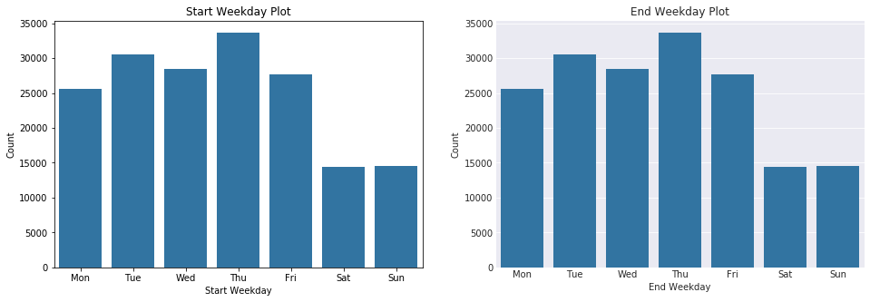

```python
plt.figure(figsize = [16, 5])
weekdays = ['Mon', 'Tue', 'Wed', 'Thu', 'Fri', 'Sat', 'Sun']
# Categorical Plot on the left start weekday
plt.subplot(1, 2, 1)
category_plot(df = df_clean, x = 'start_weekday', order = weekdays)
setplot(title = "Start Weekday Plot", x_label = "Start Weekday", y_label = "Count", x_tick = None)

# Categorical Plot on the right end weekday
plt.subplot(1, 2, 2)
category_plot(df = df_clean, x = 'end_weekday', order = weekdays)
setplot(title = "End Weekday Plot", x_label = "End Weekday", y_label = "Count", x_tick = None)
```

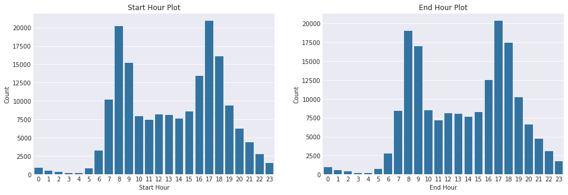

```python
plt.figure(figsize = [16, 5])
# Categorical Plot on the left start hours
plt.subplot(1, 2, 1)
category_plot(df = df_clean, x = 'start_hour')
setplot(title = "Start Hour Plot", x_label = "Start Hour", y_label = "Count", x_tick = None)

# Categorical Plot on the right end hours
plt.subplot(1, 2, 2)
category_plot(df = df_clean, x = 'end_hour')
setplot(title = "End Hour Plot", x_label = "End Hour", y_label = "Count", x_tick = None)
```

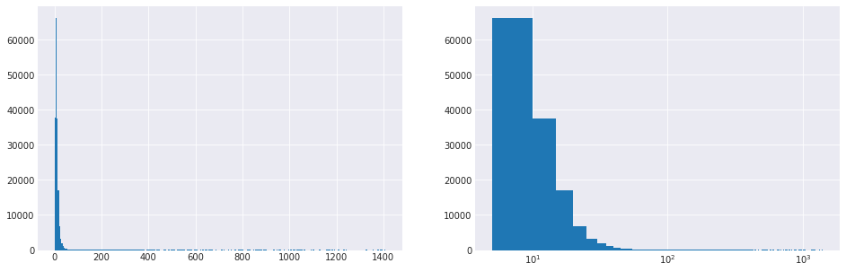

```python
plt.figure(figsize = [16, 5])
bins = np.arange(0, df_clean.duration_min.max()+5, 5)
# hist Plot on the left start hours
plt.subplot(1, 2, 1)
histplot(df = df_clean, x = 'duration_min', bins = bins)

# hist Plot on the right end hours
plt.subplot(1, 2, 2)
histplot(df = df_clean, x = 'duration_min', islog = True, bins = bins)
```

After plotting df_clean.duration_min I detected some anormalies so I investigated further using describe function

```python
df_clean.duration_min.describe(percentiles = [.99])
```

```
count    174758.000000
mean         11.742230
std          27.386444
min           1.016667
50%           8.516667
99%          52.947667
max        1409.133333
Name: duration_min, dtype: float64
```

```python
df_clean[df_clean['duration_min'] >= 55].duration_min.value_counts()
```

```
55.366667     5
55.233333     4
59.200000     4
60.216667     4
59.416667     4
63.433333     3
66.683333     3
77.033333     3
81.033333     3
72.016667     3
56.733333     3
59.683333     3
69.333333     3
58.266667     3
60.633333     3
69.233333     3
57.700000     3
57.016667     3
56.183333     3
55.216667     3
57.300000     3
57.900000     3
56.716667     3
61.566667     3
58.500000     3
58.283333     3
63.100000     3
73.133333     3
73.950000     3
64.416667     3
             ..
77.966667     1
68.550000     1
574.616667    1
81.933333     1
89.516667     1
58.716667     1
137.600000    1
323.183333    1
279.466667    1
421.883333    1
91.400000     1
58.650000     1
138.933333    1
129.316667    1
77.716667     1
216.233333    1
55.466667     1
86.383333     1
67.483333     1
91.116667     1
109.416667    1
281.116667    1
353.866667    1
131.300000    1
66.116667     1
447.050000    1
98.550000     1
65.616667     1
823.366667    1
293.333333    1
Name: duration_min, Length: 1435, dtype: int64
```

So I will plot the hist for 0 to 60

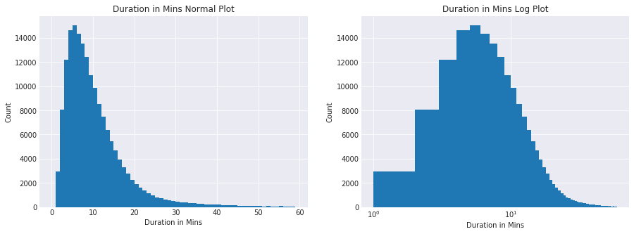

```python
plt.figure(figsize = [15, 5])
bins = np.arange(0, 60, 1)
# hist Plot on the left start hours
plt.subplot(1, 2, 1)
histplot(df = df_clean, x = 'duration_min', bins = bins)
setplot(title = "Duration in Mins Normal Plot", x_label = "Duration in Mins", y_label = "Count", x_tick = None)

# hist Plot on the right end hours
plt.subplot(1, 2, 2)
histplot(df = df_clean, x = 'duration_min', islog = True, bins = bins)
setplot(title = "Duration in Mins Log Plot", x_label = "Duration in Mins", y_label = "Count", x_tick = None)
```

```python
df_clean.distance_miles.describe(percentiles = [.99])
```

```
count    174758.000000
mean          1.050180
std           0.681557
min           0.000000
50%           0.888454
99%           3.151280
max          43.166172
Name: distance_miles, dtype: float64
```

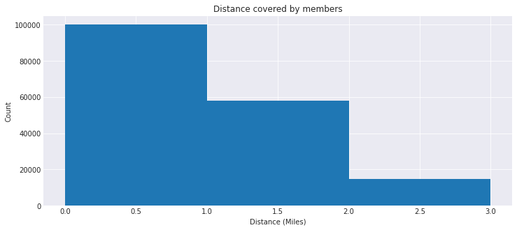

```python
plt.figure(figsize = [12, 5])
bins = np.arange(0, 4, 1)
# hist Plot for distance in miles
histplot(df = df_clean, x = 'distance_miles', bins = bins)
setplot(title = "Distance covered by members", x_label = "Distance (Miles)", y_label = "Count", x_tick = None);
```

From the distance plot we can plot a pie chart of 0-1, 1-2, and 2-3 to see the percentage of members.

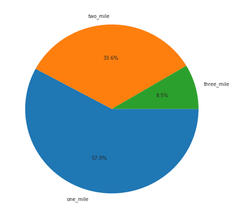

```python
one_mile = df_clean[df_clean['distance_miles'] <= 1].distance_miles.value_counts().sum()
two_mile = df_clean[df_clean['distance_miles'] <= 2].distance_miles.value_counts().sum() - one_mile
three_mile = df_clean[df_clean['distance_miles'] <= 3].distance_miles.value_counts().sum() - (two_mile + one_mile)
distance = [one_mile, two_mile, three_mile]
labels = ['one_mile', 'two_mile', 'three_mile']
distance
plt.figure(figsize = [8, 8])
plt.pie(distance, labels = labels, autopct= '%1.1f%%', counterclock = False);
```

Next I would look:

- The members ages (Histogram)
- Users types and Gender (Barplot)

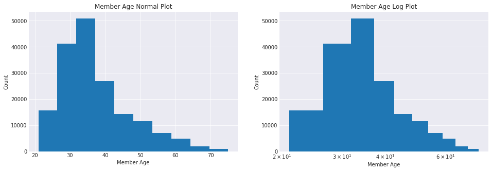

```python
# The members ages
plt.figure(figsize = [16, 5])
# hist Plot on the left
plt.subplot(1, 2, 1)
histplot(df = df_clean, x = 'member_age')
setplot(title = "Member Age Normal Plot", x_label = "Member Age", y_label = "Count", x_tick = None)

# hist log Plot on the right
plt.subplot(1, 2, 2)
histplot(df = df_clean, x = 'member_age', islog = True)
setplot(title = "Member Age Log Plot", x_label = "Member Age", y_label = "Count", x_tick = None)
```

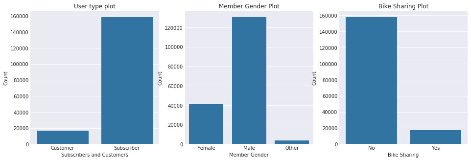

```python
# Users types (Barplot)
plt.figure(figsize = [16, 5])
# Categorical Plot on the left Users types
plt.subplot(1, 3, 1)
category_plot(df = df_clean, x = 'user_type')
setplot(title = "User type plot", x_label = "Subscribers and Customers",
        y_label = "Count", x_tick = None)

# Categorical Plot on the middle gender
plt.subplot(1, 3, 2)
category_plot(df = df_clean, x = 'member_gender')
setplot(title = "Member Gender Plot", x_label = "Member Gender",
        y_label = "Count", x_tick = None)

# Categorical Plot on the right bike_share_for_all_trip
plt.subplot(1, 3, 3)
category_plot(df = df_clean, x = 'bike_share_for_all_trip')
setplot(title = "Bike Sharing Plot", x_label = "Bike Sharing",
        y_label = "Count", x_tick = None)
```

**Observations:**

1. Tuesdays and Thursday seem to be the most popular days for using the bike sharing system, however Wednesday, Mondays and Fridays are very close to the Tues/Weds numbers. The usage drops significantly on Saturdays and Sundays suggesting the Ford bike share system is primarily used during working days.
2. Bikes usage hours shows the most numbers between the hours of 8-9am and 5-6pm, which reflects the typical work day in the US.
3. The percentiles and plot shows that most rides falls between 3 and 12 minutes, therefore most riders tahe bikes for short distance. This is also visible in the Distance plots.

### Discuss the distribution(s) of your variable(s) of interest. Were there any unusual points? Did you need to perform any transformations?

> As stated during the exploration visualizations phase, the only unusual points noticed was the skewed nature of the distance and durations, which was fairly the same even after transformation.

### Of the features you investigated, were there any unusual distributions? Did you perform any operations on the data to tidy, adjust, or change the form of the data? If so, why did you do this?

> Same as above.

## Bivariate Exploration

> In this section, investigate relationships between pairs of variables initially explored in the previous section (univariate exploration).

**Plots of insterest:**

- gender vs user_type (barplot customers/subscribers)
- member_age vs distance covered (scatter plot)
- member_age vs user type (box/violin_plot customers/subscribers)
- trip duration vs user type (box/violin_plot customers/subscribers)
- trip duration vs gender (box/violin_plot customers/subscribers)

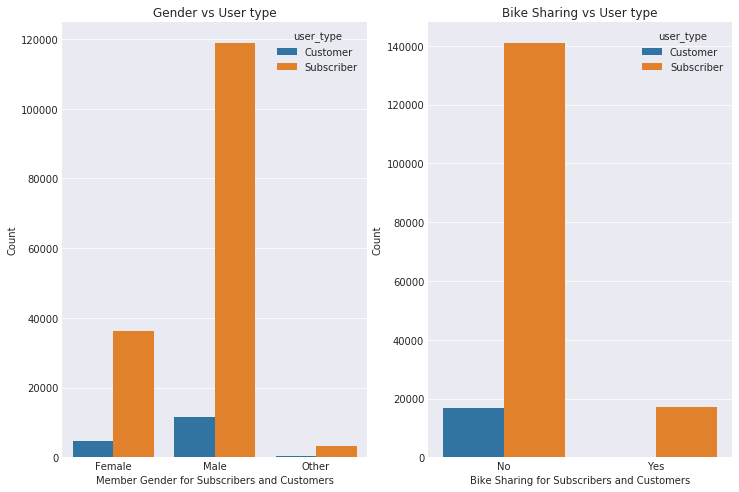

```python
# Gender vs User_type
plt.figure(figsize = [12, 8])
# Categorical Plot of gender vs customer user_type
plt.subplot(1, 2, 1)
category_plot(df = df_clean, x = 'member_gender', hue = 'user_type', off = False)

setplot(title = "Gender vs User type", x_label = "Member Gender for Subscribers and Customers",
        y_label = "Count", x_tick = None)

# Categorical Plot of bike_share_for_all_trip vs customer user_type
plt.subplot(1, 2, 2)
category_plot(df = df_clean, x = 'bike_share_for_all_trip', hue = 'user_type', off = False)

setplot(title = "Bike Sharing vs User type", x_label = "Bike Sharing for Subscribers and Customers",
        y_label = "Count", x_tick = None)
```

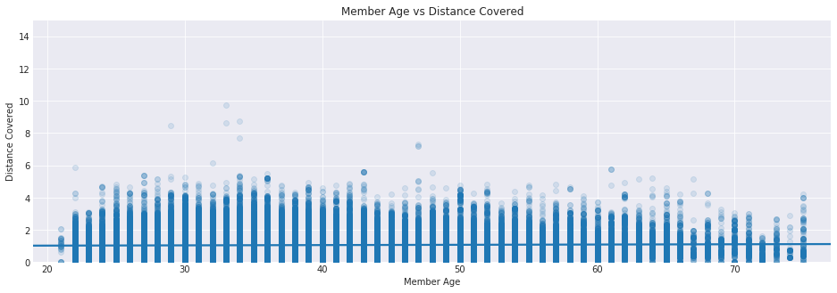

```python
# Member Age vs Distance Covered
plt.figure(figsize = [16, 5])
# Scattered Plot of member_age vs distance covered
scatterplot(df = df_clean, x = 'member_age', y = 'distance_miles', fit_reg = True, alpha = 1/8)

setplot(title = "Member Age vs Distance Covered", x_label = 'Member Age',
        y_label = 'Distance Covered', x_tick = None)

# control x and y limits
plt.xlim(df_clean.member_age.min()-2, df_clean.member_age.max()+2);
plt.ylim(0, 15);
```

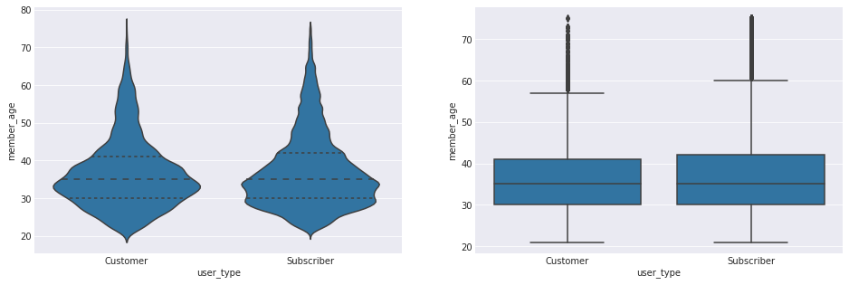

```python
# member_age vs user type (box/violin_plot customers/subscribers)
plt.figure(figsize = [16, 5])
# Categorical Plot on the left Violin Plot
plt.subplot(1, 2, 1)
v_boxplot(df = df_clean, x = 'user_type', y = 'member_age', kind = True, inner = 'quartile')

# Categorical Plot on the right Boxplot
plt.subplot(1, 2, 2)
v_boxplot(df = df_clean, x = 'user_type', y = 'member_age')
```

Since Trip Duration was skewed we will plot for the first 45 min

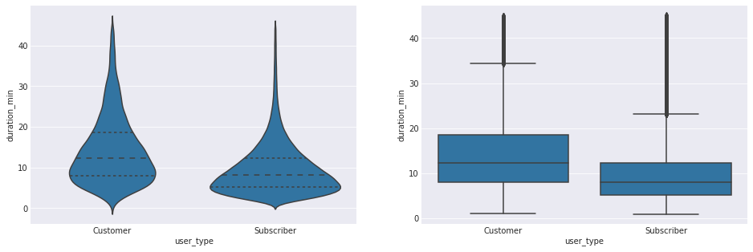

```python
# Trip Duration in minutes vs User_type
df_trip = df_clean.query('duration_min < 45')
plt.figure(figsize = [16, 5])
# Categorical Plot on the left Violin Plot
plt.subplot(1, 2, 1)
v_boxplot(df = df_trip, x = 'user_type', y = 'duration_min', kind = True, inner = 'quartile');

# Categorical Plot on the right Boxplot
plt.subplot(1, 2, 2)
v_boxplot(df = df_trip, x = 'user_type', y = 'duration_min');
```

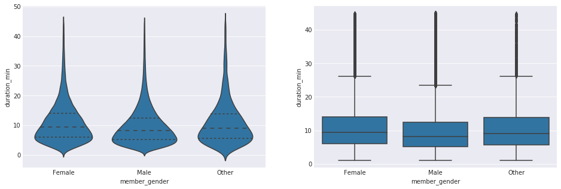

```python
# Trip Duration in minutes vs Member Gender
df_trip = df_clean.query('duration_min < 45')
plt.figure(figsize = [16, 5])
# Categorical Plot on the left Violin Plot
plt.subplot(1, 2, 1)
v_boxplot(df = df_trip, x = 'member_gender', y = 'duration_min', kind = True, inner = 'quartile');

# Categorical Plot on the right Boxplot
plt.subplot(1, 2, 2)
v_boxplot(df = df_trip, x = 'member_gender', y = 'duration_min');
```

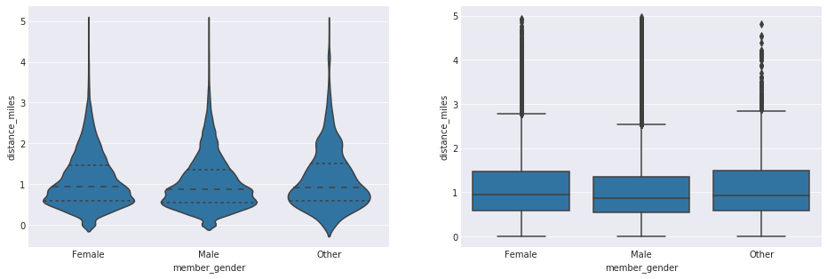

```python
# Trip Duration in minutes vs Member Gender
df_dist = df_clean.query('distance_miles < 5')
plt.figure(figsize = [16, 5])
# Categorical Plot on the left Violin Plot
plt.subplot(1, 2, 1)
v_boxplot(df = df_dist, x = 'member_gender', y = 'distance_miles', kind = True, inner = 'quartile');

# Categorical Plot on the right Boxplot
plt.subplot(1, 2, 2)
v_boxplot(df = df_dist, x = 'member_gender', y = 'distance_miles');
```

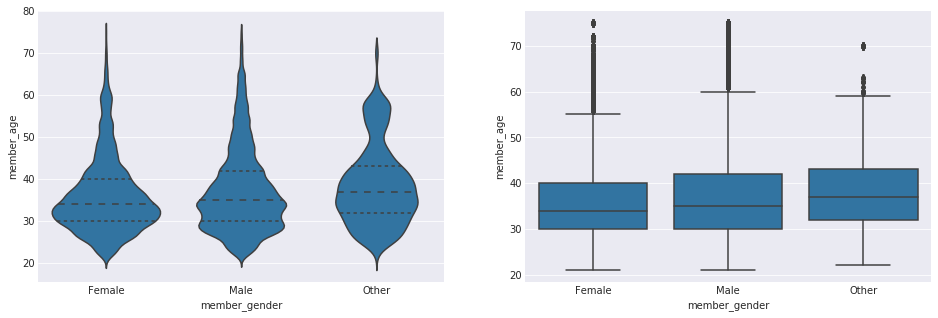

```python
# Member Age vs Member Gender
plt.figure(figsize = [16, 5])
# Categorical Plot on the left Violin Plot
plt.subplot(1, 2, 1)
v_boxplot(df = df_clean, x = 'member_gender', y = 'member_age', kind = True, inner = 'quartile');

# Categorical Plot on the right Boxplot
plt.subplot(1, 2, 2)
v_boxplot(df = df_clean, x = 'member_gender', y = 'member_age');
```

### Did you observe any interesting relationships between the other features (not the main feature(s) of interest)?

- Interestingly, females on average spent more time on trips and covered more distance.

## Multivariate Exploration

> To investigate my data further I would Create plots of three or more variables of my work in the previous sections.

**Plots of insterest:**

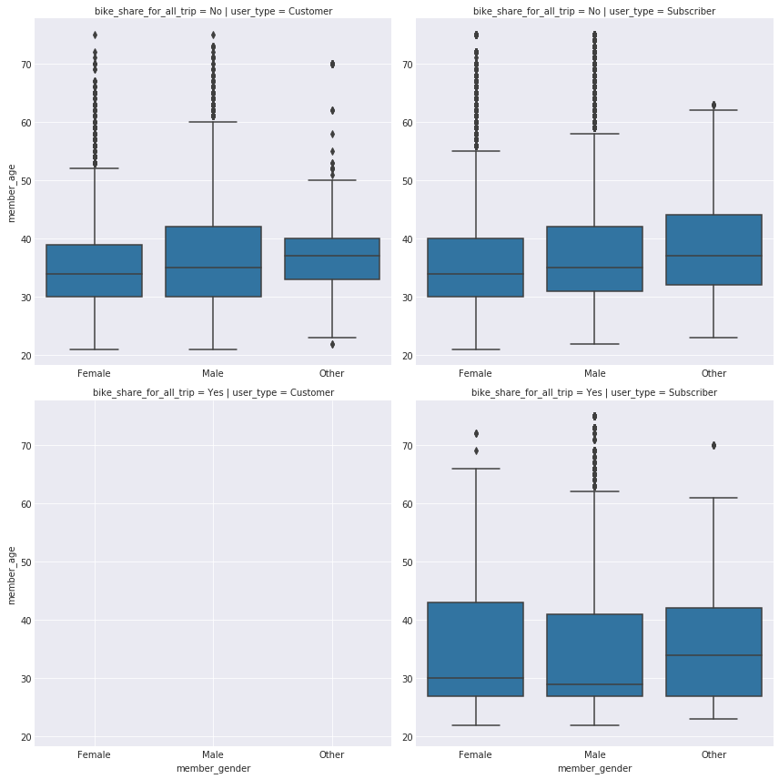

```python
g = sb.FacetGrid(data = df_clean, col = 'user_type', row = 'bike_share_for_all_trip', size = 6);
g.map_dataframe(sb.boxplot, 'member_gender', 'member_age');
```

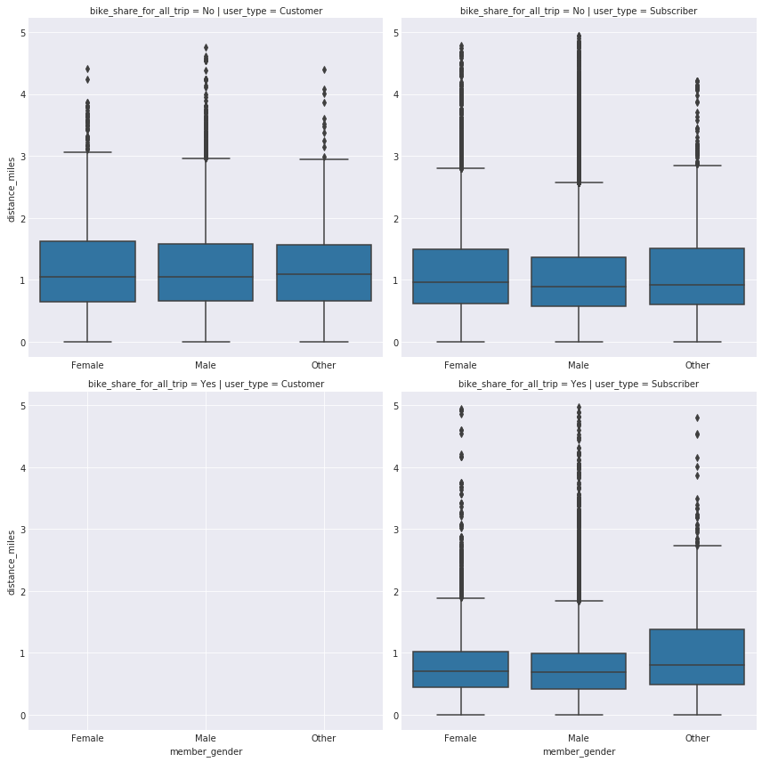

```python
df_dist = df_clean.query('distance_miles < 5')

g = sb.FacetGrid(data = df_dist, col = 'user_type', row = 'bike_share_for_all_trip', size = 6);
g.map_dataframe(sb.boxplot, 'member_gender', 'distance_miles');
```

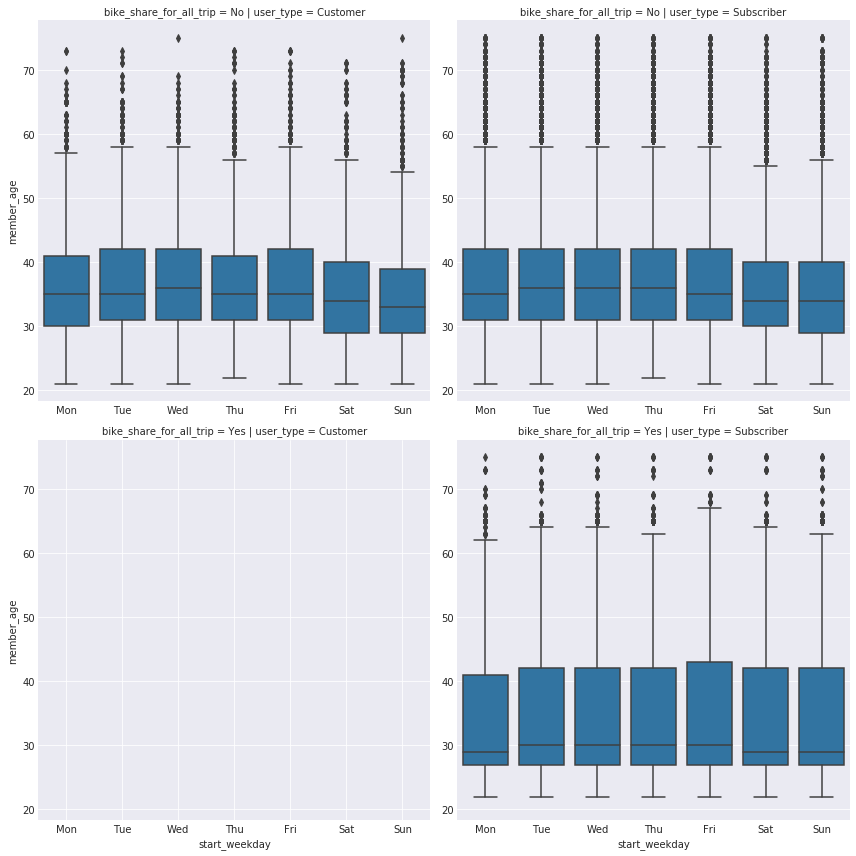

```python
weekdays = ['Mon', 'Tue', 'Wed', 'Thu', 'Fri', 'Sat', 'Sun']

g = sb.FacetGrid(data = df_clean, col = 'user_type', row = 'bike_share_for_all_trip', size = 6);
g.map_dataframe(sb.boxplot, 'start_weekday', 'member_age', order = weekdays);
```

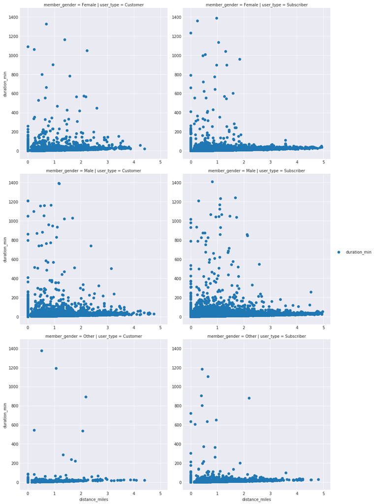

```python
df_dist = df_clean.query('distance_miles < 5')

g = sb.FacetGrid(data = df_dist, col = 'user_type', row = 'member_gender', size = 6);
g.map_dataframe(plt.scatter, 'distance_miles', 'duration_min');
g.add_legend();
```

### Talk about some of the relationships you observed in this part of the investigation. Were there features that strengthened each other in terms of looking at your feature(s) of interest?

This sections extends on previous sections and shows that:

- no customer shared bikes on trips,
- Average ages of users not sharing bikes through out all trips was more than those sharing.
- Same applied to gender.

### Were there any interesting or surprising interactions between features?

Data showed a fairly consistent result with the previous sections.